# Sleep

# 1 Description of DataSchema variable

The description of harmonised variable is the following:

- Short name: `sleep`
- Variable label: `Sleep`
- Variable description: `Sleeping problems.`
- Domain: `Health status and functional limitations`
- Value type: `categorical`
- Category coding:

| **Code** | **Category Label** |
| --- | --- |
| 0 | Yes |
| 1 | No |

- Category missings:

| **Code** | **Category Label** |
| --- | --- |
| 991 | CAPI/interviewer error |
| 992 | Impute |
| 993 | Disable to measure |
| 994 | Not attempt/not done |
| 995 | Does not answer |
| 996 | Not applicable |
| 997 | Refuse |
| 998 | Do not know |
| 999 | Missing |

# 2 Data process

## 2.1 England

### 2.1.1 Wave 1

#### 2.1.1.1 Study-specific variable description

| **Name** | `pscedc` |
| --- | --- |
| **Label** | `Much of the time during the past week, has your sleep been restless?` |
| **Table name** | `wave_1_core_data_v3` |
| **Categories** | `1 = Yes; 2 = No` |
| **Missings** | `-9 = Refusal; -8 = Don't Know; -1 = Not applicable` |
| **Description** |  |

pscedc

| Sample size | Missing values |
| --- | --- |
| 12099 | 381 |

Category

|  | 1 | 2 |
| --- | --- | --- |
| Frequency | 4776.00 | 6942.00 |
| Percentage | 39.47 | 57.38 |

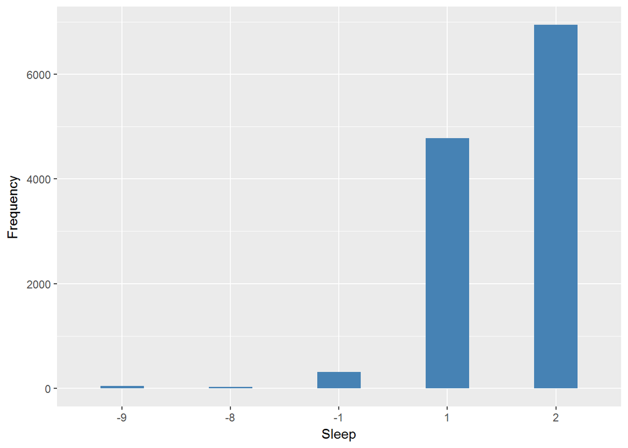

#### 2.1.1.2 Harmonisation algorithm

To compute the harmonize variable from the study-specific variable it has to be recoded as follows:

- `1 into 0`
- `2 into 1`
- `-9 Refusal into 997`
- `-8 Don't know into 998`
- `-1 Not applicable into 996`

**R script:**

```r
ELSA_ds_w1 <- tibble(id = ELSA_w1_sleep$id)
ELSA_ds_w1$sleep <- car::recode(ELSA_w1_sleep$pscedc, "1 = '0';2 = '1';-9 = '997';-8 = '998';-1 = '996' ")
ELSA_ds_w1$sleep <- labelled(ELSA_ds_w1$sleep, labels = c(Yes = 0, No = 1, Missing = 999,
    Do_not_know = 998, Refuse = 997, Not_applicable = 996, Does_not_answer = 995,
    Not_attempt_not_done = 994, Disable_to_measure = 993, Impute = 992, CAPI_interviewer_error = 991))
```

#### 2.1.1.3 Statistical description of the new harmonised variable

sleep

| Sample size | Missing values |
| --- | --- |
| 12099 | 381 |

Category

|  | 0 | 1 |
| --- | --- | --- |
| Frequency | 4776.00 | 6942.00 |
| Percentage | 39.47 | 57.38 |

Type of missing

|  | 991 | 992 | 993 | 994 | 995 | 996 | 997 | 998 | 999 | NA |
| --- | --- | --- | --- | --- | --- | --- | --- | --- | --- | --- |
| Frequency | 0 | 0 | 0 | 0 | 0 | 311.00 | 43.00 | 27.00 | 0 | 0 |
| Percentage | 0 | 0 | 0 | 0 | 0 | 2.57 | 0.36 | 0.22 | 0 | 0 |

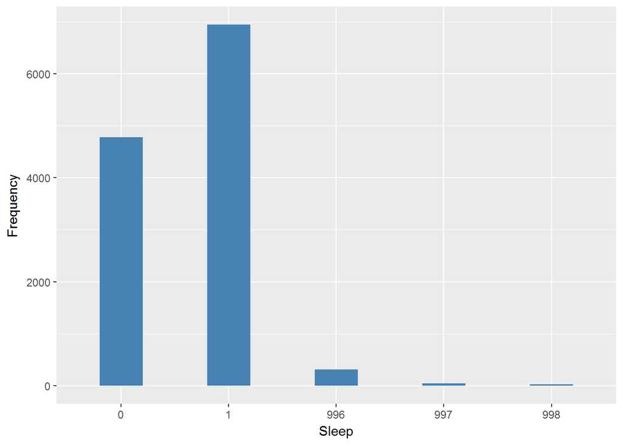

#### 2.1.1.4 Validation

|  | 1->0 | 2->1 | -1->996 | -9->997 | -8->998 |
| --- | --- | --- | --- | --- | --- |
| BeforeH | 4776 | 6942 | 311 | 43 | 27 |
| AfterH | 4776 | 6942 | 311 | 43 | 27 |

### 2.1.2 Wave 2

#### 2.1.2.1 Study-specific variable description

| **Name** | `PScedC` |
| --- | --- |
| **Label** | `Whether respondent felt their sleep was restless during the past week?` |
| **Table name** | `wave_2_core_data_v4` |
| **Categories** | `1 = Yes; 2 = No` |
| **Missings** | `-9 = Refusal; -8 = Don't Know; -1 = Not applicable` |
| **Description** |  |

PScedC

| Sample size | Missing values |
| --- | --- |
| 9432 | 219 |

Category

|  | 1 | 2 |
| --- | --- | --- |
| Frequency | 3885.00 | 5328.00 |
| Percentage | 41.19 | 56.49 |

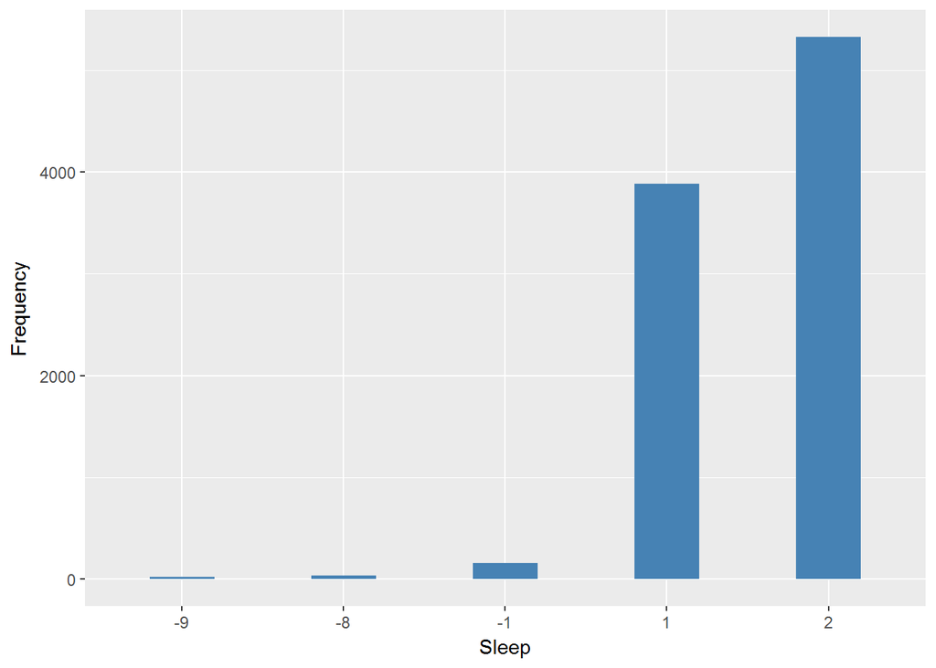

#### 2.1.2.2 Harmonisation algorithm

To compute the harmonize variable from the study-specific variable it has to be recoded as follows:

- `1 into 0`
- `2 into 1`
- `-9 Refusal into 997`
- `-8 Don't know into 998`
- `-1 Not applicable into 996`

**R script:**

```r
ELSA_ds_w2 <- tibble(id = ELSA_w2_sleep$id)
ELSA_ds_w2$sleep <- car::recode(ELSA_w2_sleep$PScedC, "1 = '0';2 = '1';-9 = '997';-8 = '998';-1 = '996' ")
ELSA_ds_w2$sleep <- labelled(ELSA_ds_w2$sleep, labels = c(Yes = 0, No = 1, Missing = 999,
    Do_not_know = 998, Refuse = 997, Not_applicable = 996, Does_not_answer = 995,
    Not_attempt_not_done = 994, Disable_to_measure = 993, Impute = 992, CAPI_interviewer_error = 991))
```

#### 2.1.2.3 Statistical description of the new harmonised variable

sleep

| Sample size | Missing values |
| --- | --- |
| 9432 | 219 |

Category

|  | 0 | 1 |
| --- | --- | --- |
| Frequency | 3885.00 | 5328.00 |
| Percentage | 41.19 | 56.49 |

Type of missing

|  | 991 | 992 | 993 | 994 | 995 | 996 | 997 | 998 | 999 | NA |
| --- | --- | --- | --- | --- | --- | --- | --- | --- | --- | --- |
| Frequency | 0 | 0 | 0 | 0 | 0 | 159.00 | 23.00 | 37.00 | 0 | 0 |
| Percentage | 0 | 0 | 0 | 0 | 0 | 1.69 | 0.24 | 0.39 | 0 | 0 |

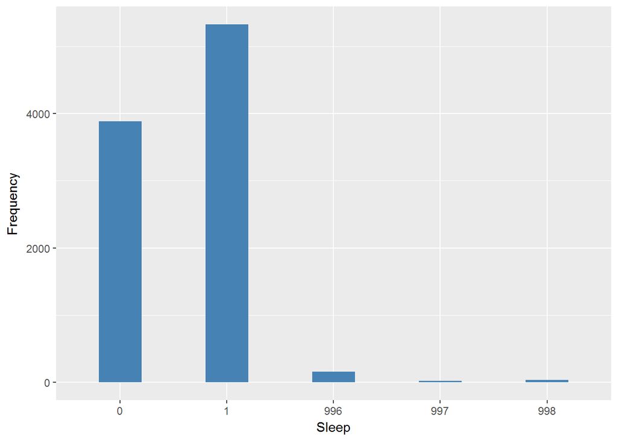

#### 2.1.2.4 Validation

|  | 1->0 | 2->1 | -1->996 | -9->997 | -8->998 |
| --- | --- | --- | --- | --- | --- |
| BeforeH | 3885 | 5328 | 159 | 23 | 37 |
| AfterH | 3885 | 5328 | 159 | 23 | 37 |

### 2.1.3 Wave 3

#### 2.1.3.1 Study-specific variable description

| **Name** | `pscedc` |
| --- | --- |
| **Label** | `Whether felt their sleep was restless during past week?` |
| **Table name** | `wave_3_elsa_data_v4` |
| **Categories** | `1 = Yes; 2 = No` |
| **Missings** | `-9 = Refusal; -8 = Don't Know; -1 = Not applicable` |
| **Description** |  |

pscedc

| Sample size | Missing values |
| --- | --- |
| 9771 | 311 |

Category

|  | 1 | 2 |
| --- | --- | --- |
| Frequency | 3891.00 | 5569 |
| Percentage | 39.82 | 57 |

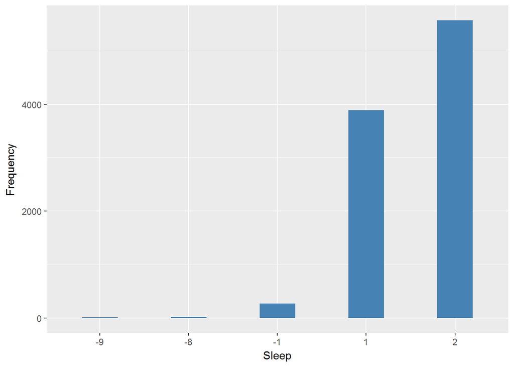

#### 2.1.3.2 Harmonisation algorithm

To compute the harmonize variable from the study-specific variable it has to be recoded as follows:

- `1 into 0`
- `2 into 1`
- `-9 Refusal into 997`
- `-8 Don't know into 998`
- `-1 Not applicable into 996`

**R script:**

```r
ELSA_ds_w3 <- tibble(id = ELSA_w3_sleep$id)
ELSA_ds_w3$sleep <- car::recode(ELSA_w3_sleep$pscedc, "1 = '0';2 = '1';-9 = '997';-8 = '998';-1 = '996' ")
ELSA_ds_w3$sleep <- labelled(ELSA_ds_w3$sleep, labels = c(Yes = 0, No = 1, Missing = 999,
    Do_not_know = 998, Refuse = 997, Not_applicable = 996, Does_not_answer = 995,
    Not_attempt_not_done = 994, Disable_to_measure = 993, Impute = 992, CAPI_interviewer_error = 991))
```

#### 2.1.3.3 Statistical description of the new harmonised variable

sleep

| Sample size | Missing values |
| --- | --- |
| 9771 | 311 |

Category

|  | 0 | 1 |
| --- | --- | --- |
| Frequency | 3891.00 | 5569 |
| Percentage | 39.82 | 57 |

Type of missing

|  | 991 | 992 | 993 | 994 | 995 | 996 | 997 | 998 | 999 | NA |
| --- | --- | --- | --- | --- | --- | --- | --- | --- | --- | --- |
| Frequency | 0 | 0 | 0 | 0 | 0 | 276.00 | 12.00 | 23.00 | 0 | 0 |
| Percentage | 0 | 0 | 0 | 0 | 0 | 2.82 | 0.12 | 0.24 | 0 | 0 |

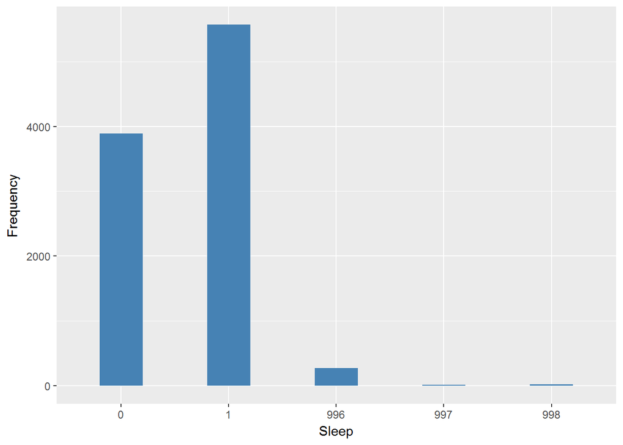

#### 2.1.3.4 Validation

|  | 1->0 | 2->1 | -1->996 | -9->997 | -8->998 |
| --- | --- | --- | --- | --- | --- |
| BeforeH | 3891 | 5569 | 276 | 12 | 23 |
| AfterH | 3891 | 5569 | 276 | 12 | 23 |

### 2.1.4 Wave 4

#### 2.1.4.1 Study-specific variable description

| **Name** | `pscedc` |
| --- | --- |
| **Label** | `Whether felt their sleep was restless during past week?` |
| **Table name** | `wave_4_elsa_data_v3` |
| **Categories** | `1 = Yes; 2 = No` |
| **Missings** | `-9 = Refusal; -8 = Don't Know; -1 = Not applicable` |
| **Description** |  |

pscedc

| Sample size | Missing values |
| --- | --- |
| 11050 | 520 |

Category

|  | 1 | 2 |
| --- | --- | --- |
| Frequency | 3697.00 | 6833.00 |
| Percentage | 33.46 | 61.84 |

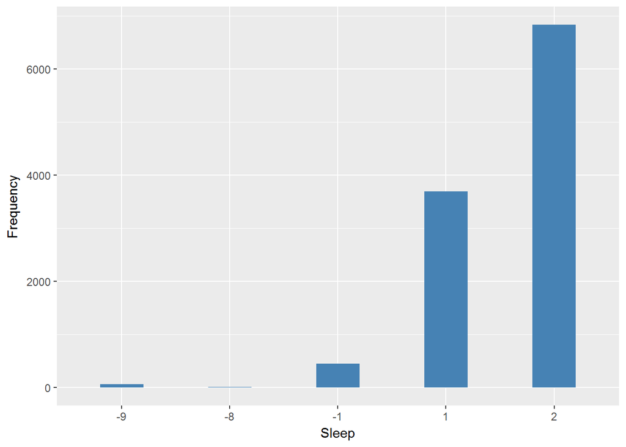

#### 2.1.4.2 Harmonisation algorithm

To compute the harmonize variable from the study-specific variable it has to be recoded as follows:

- `1 into 0`
- `2 into 1`
- `-9 Refusal into 997`
- `-8 Don't know into 998`
- `-1 Not applicable into 996`

**R script:**

```r
ELSA_ds_w4 <- tibble(id = ELSA_w4_sleep$id)
ELSA_ds_w4$sleep <- car::recode(ELSA_w4_sleep$pscedc, "1 = '0';2 = '1';-9 = '997';-8 = '998';-1 = '996' ")
ELSA_ds_w4$sleep <- labelled(ELSA_ds_w4$sleep, labels = c(Yes = 0, No = 1, Missing = 999,
    Do_not_know = 998, Refuse = 997, Not_applicable = 996, Does_not_answer = 995,
    Not_attempt_not_done = 994, Disable_to_measure = 993, Impute = 992, CAPI_interviewer_error = 991))
```

#### 2.1.4.3 Statistical description of the new harmonised variable

sleep

| Sample size | Missing values |
| --- | --- |
| 11050 | 520 |

Category

|  | 0 | 1 |
| --- | --- | --- |
| Frequency | 3697.00 | 6833.00 |
| Percentage | 33.46 | 61.84 |

Type of missing

|  | 991 | 992 | 993 | 994 | 995 | 996 | 997 | 998 | 999 | NA |
| --- | --- | --- | --- | --- | --- | --- | --- | --- | --- | --- |
| Frequency | 0 | 0 | 0 | 0 | 0 | 446.00 | 61.00 | 13.00 | 0 | 0 |
| Percentage | 0 | 0 | 0 | 0 | 0 | 4.04 | 0.55 | 0.12 | 0 | 0 |

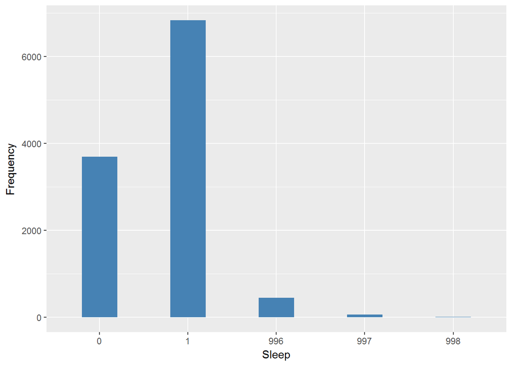

#### 2.1.4.4 Validation

|  | 1->0 | 2->1 | -1->996 | -9->997 | -8->998 |
| --- | --- | --- | --- | --- | --- |
| BeforeH | 3697 | 6833 | 446 | 61 | 13 |
| AfterH | 3697 | 6833 | 446 | 61 | 13 |

### 2.1.5 Wave 5

#### 2.1.5.1 Study-specific variable description

| **Name** | `pscedc` |
| --- | --- |
| **Label** | `Whether felt their sleep was restless during past week?` |
| **Table name** | `wave_5_elsa_data_v4` |
| **Categories** | `1 = Yes; 2 = No` |
| **Missings** | `-9 = Refusal; -8 = Don't Know; -1 = Not applicable` |
| **Description** |  |

pscedc

| Sample size | Missing values |
| --- | --- |
| 10274 | 626 |

Category

|  | 1 | 2 |
| --- | --- | --- |
| Frequency | 3980.00 | 5668.00 |
| Percentage | 38.74 | 55.17 |

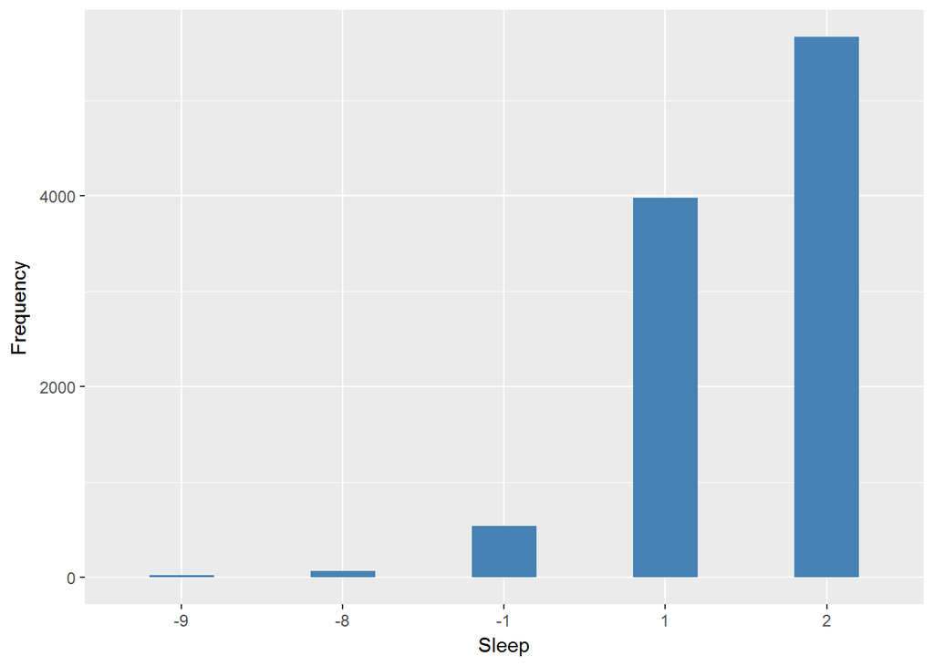

#### 2.1.5.2 Harmonisation algorithm

To compute the harmonize variable from the study-specific variable it has to be recoded as follows:

- `1 into 0`
- `2 into 1`
- `-9 Refusal into 997`
- `-8 Don't know into 998`
- `-1 Not applicable into 996`

**R script:**

```r
ELSA_ds_w5 <- tibble(id = ELSA_w5_sleep$id)
ELSA_ds_w5$sleep <- car::recode(ELSA_w5_sleep$pscedc, "1 = '0';2 = '1';-9 = '997';-8 = '998';-1 = '996' ")
ELSA_ds_w5$sleep <- labelled(ELSA_ds_w5$sleep, labels = c(Yes = 0, No = 1, Missing = 999,
    Do_not_know = 998, Refuse = 997, Not_applicable = 996, Does_not_answer = 995,
    Not_attempt_not_done = 994, Disable_to_measure = 993, Impute = 992, CAPI_interviewer_error = 991))
```

#### 2.1.5.3 Statistical description of the new harmonised variable

sleep

| Sample size | Missing values |
| --- | --- |
| 10274 | 626 |

Category

|  | 0 | 1 |
| --- | --- | --- |
| Frequency | 3980.00 | 5668.00 |
| Percentage | 38.74 | 55.17 |

Type of missing

|  | 991 | 992 | 993 | 994 | 995 | 996 | 997 | 998 | 999 | NA |
| --- | --- | --- | --- | --- | --- | --- | --- | --- | --- | --- |
| Frequency | 0 | 0 | 0 | 0 | 0 | 537.00 | 25.00 | 64.00 | 0 | 0 |
| Percentage | 0 | 0 | 0 | 0 | 0 | 5.23 | 0.24 | 0.62 | 0 | 0 |

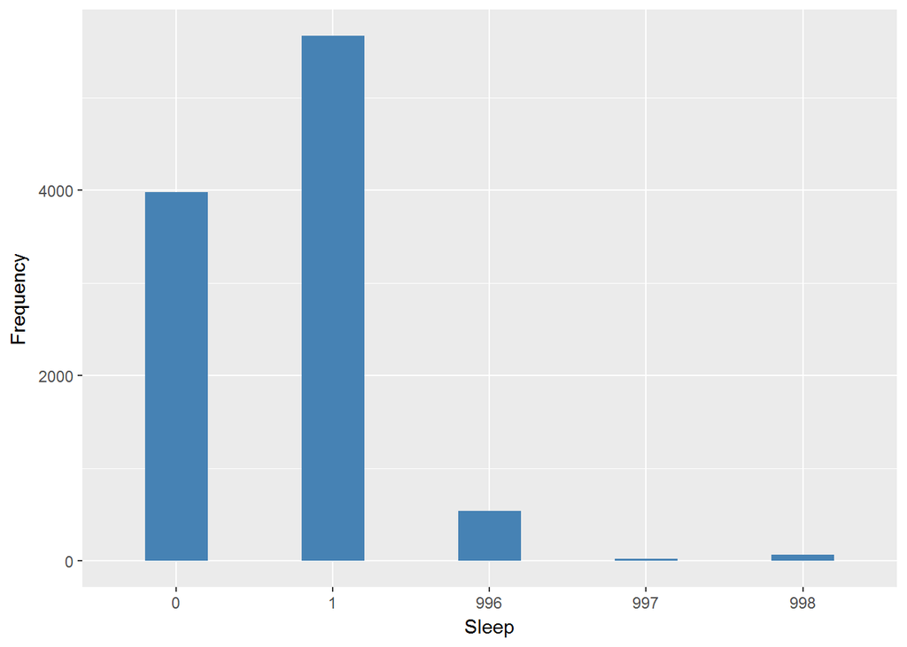

#### 2.1.5.4 Validation

|  | 1->0 | 2->1 | -1->996 | -9->997 | -8->998 |
| --- | --- | --- | --- | --- | --- |
| BeforeH | 3980 | 5668 | 537 | 25 | 64 |
| AfterH | 3980 | 5668 | 537 | 25 | 64 |

### 2.1.6 Wave 6

#### 2.1.6.1 Study-specific variable description

[output not shown]

PScedC

| Sample size | Missing values |
| --- | --- |
| 10601 | 682 |

Category

|  | 1 | 2 |
| --- | --- | --- |
| Frequency | 3428.00 | 6491.00 |
| Percentage | 32.34 | 61.23 |

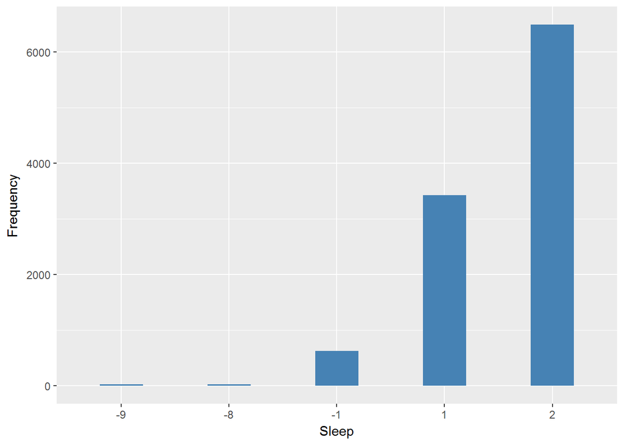

#### 2.1.6.2 Harmonisation algorithm

To compute the harmonize variable from the study-specific variable it has to be recoded as follows:

- `1 into 0`
- `2 into 1`
- `-9 Refusal into 997`
- `-8 Don't know into 998`
- `-1 Not applicable into 996`

**R script:**

```r
ELSA_ds_w6 <- tibble(id = ELSA_w6_sleep$id)
ELSA_ds_w6$sleep <- car::recode(ELSA_w6_sleep$PScedC, "1 = '0';2 = '1';-9 = '997';-8 = '998';-1 = '996' ")
ELSA_ds_w6$sleep <- labelled(ELSA_ds_w6$sleep, labels = c(Yes = 0, No = 1, Missing = 999,
    Do_not_know = 998, Refuse = 997, Not_applicable = 996, Does_not_answer = 995,
    Not_attempt_not_done = 994, Disable_to_measure = 993, Impute = 992, CAPI_interviewer_error = 991))
```

#### 2.1.6.3 Statistical description of the new harmonised variable

sleep

| Sample size | Missing values |
| --- | --- |
| 10601 | 682 |

Category

|  | 0 | 1 |
| --- | --- | --- |
| Frequency | 3428.00 | 6491.00 |
| Percentage | 32.34 | 61.23 |

Type of missing

|  | 991 | 992 | 993 | 994 | 995 | 996 | 997 | 998 | 999 | NA |
| --- | --- | --- | --- | --- | --- | --- | --- | --- | --- | --- |
| Frequency | 0 | 0 | 0 | 0 | 0 | 627.00 | 28.00 | 27.00 | 0 | 0 |
| Percentage | 0 | 0 | 0 | 0 | 0 | 5.91 | 0.26 | 0.25 | 0 | 0 |

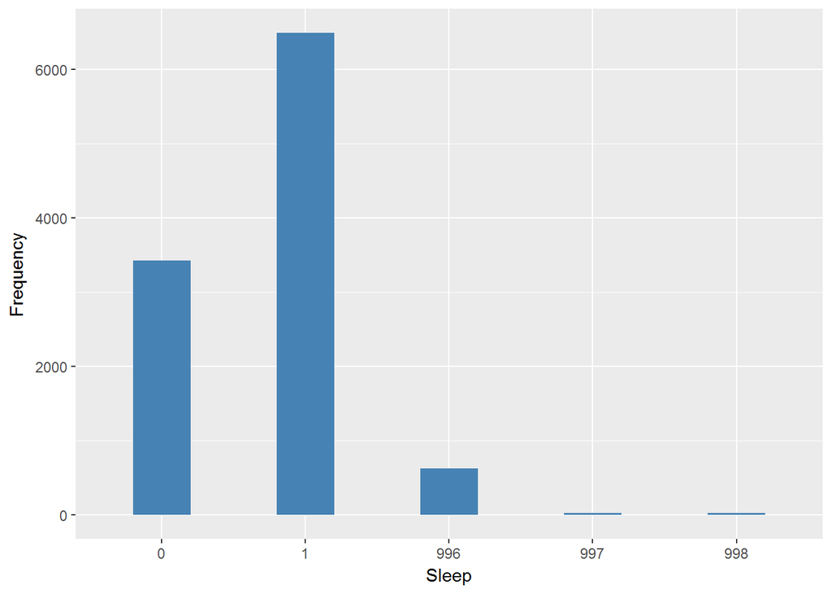

#### 2.1.6.4 Validation

|  | 1->0 | 2->1 | -1->996 | -9->997 | -8->998 |
| --- | --- | --- | --- | --- | --- |
| BeforeH | 3428 | 6491 | 627 | 28 | 27 |
| AfterH | 3428 | 6491 | 627 | 28 | 27 |

### 2.1.7 Wave 7

#### 2.1.7.1 Study-specific variable description

[output not shown]

PScedC

| Sample size | Missing values |
| --- | --- |
| 9666 | 669 |

Category

|  | 1 | 2 |
| --- | --- | --- |
| Frequency | 3663.0 | 5334.00 |
| Percentage | 37.9 | 55.18 |

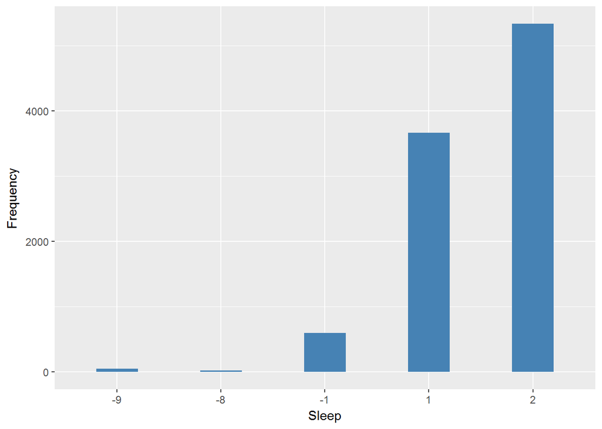

#### 2.1.7.2 Harmonisation algorithm

To compute the harmonize variable from the study-specific variable it has to be recoded as follows:

- `1 into 0`
- `2 into 1`
- `-9 Refusal into 997`
- `-8 Don't know into 998`
- `-1 Not applicable into 996`

**R script:**

```r
ELSA_ds_w7 <- tibble(id = ELSA_w7_sleep$id)
ELSA_ds_w7$sleep <- car::recode(ELSA_w7_sleep$PScedC, "1 = '0';2 = '1';-9 = '997';-8 = '998';-1 = '996' ")
ELSA_ds_w7$sleep <- labelled(ELSA_ds_w7$sleep, labels = c(Yes = 0, No = 1, Missing = 999,
    Do_not_know = 998, Refuse = 997, Not_applicable = 996, Does_not_answer = 995,
    Not_attempt_not_done = 994, Disable_to_measure = 993, Impute = 992, CAPI_interviewer_error = 991))
```

#### 2.1.7.3 Statistical description of the new harmonised variable

sleep

| Sample size | Missing values |
| --- | --- |
| 9666 | 669 |

Category

|  | 0 | 1 |
| --- | --- | --- |
| Frequency | 3663.0 | 5334.00 |
| Percentage | 37.9 | 55.18 |

Type of missing

|  | 991 | 992 | 993 | 994 | 995 | 996 | 997 | 998 | 999 | NA |
| --- | --- | --- | --- | --- | --- | --- | --- | --- | --- | --- |
| Frequency | 0 | 0 | 0 | 0 | 0 | 597.00 | 49.00 | 23.00 | 0 | 0 |
| Percentage | 0 | 0 | 0 | 0 | 0 | 6.18 | 0.51 | 0.24 | 0 | 0 |

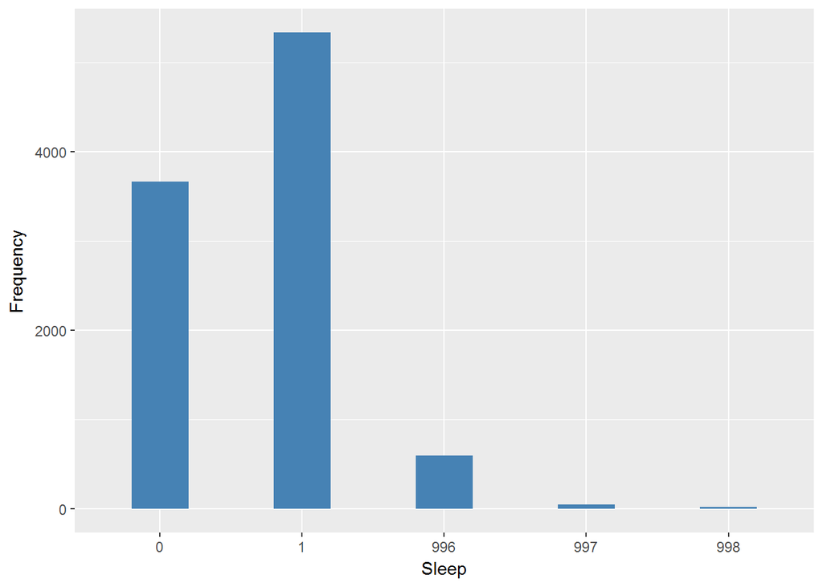

#### 2.1.7.4 Validation

|  | 1->0 | 2->1 | -1->996 | -9->997 | -8->998 |
| --- | --- | --- | --- | --- | --- |
| BeforeH | 3663 | 5334 | 597 | 49 | 23 |
| AfterH | 3663 | 5334 | 597 | 49 | 23 |

## 2.2 Summary of descriptive statistics of the harmonised variable accross populations and waves

Two tables are generated:

1. Percentages of categories in each harmonised variable.
2. Frequencies and percentages of individuals with different trajectories. To avoid too large table, Only trajectories with percentages larger than 0.3 are shown.

**R script:**

```r
ELSA_ds_w1$sleep <- labelled(ELSA_ds_w1$sleep, labels = c(Presence = 0, Absence = 1,
    Missing = 999, Do_not_know = 998, Refuse = 997, Not_applicable = 996, Does_not_answer = 995,
    Not_attempt_not_done = 994, Disable_to_measure = 993, Impute = 992, CAPI_interviewer_error = 991))
ELSA_ds_w2$sleep <- labelled(ELSA_ds_w2$sleep, labels = c(Presence = 0, Absence = 1,
    Missing = 999, Do_not_know = 998, Refuse = 997, Not_applicable = 996, Does_not_answer = 995,
    Not_attempt_not_done = 994, Disable_to_measure = 993, Impute = 992, CAPI_interviewer_error = 991))
ELSA_ds_w3$sleep <- labelled(ELSA_ds_w3$sleep, labels = c(Presence = 0, Absence = 1,
    Missing = 999, Do_not_know = 998, Refuse = 997, Not_applicable = 996, Does_not_answer = 995,
    Not_attempt_not_done = 994, Disable_to_measure = 993, Impute = 992, CAPI_interviewer_error = 991))
ELSA_ds_w4$sleep <- labelled(ELSA_ds_w4$sleep, labels = c(Presence = 0, Absence = 1,
    Missing = 999, Do_not_know = 998, Refuse = 997, Not_applicable = 996, Does_not_answer = 995,
    Not_attempt_not_done = 994, Disable_to_measure = 993, Impute = 992, CAPI_interviewer_error = 991))
ELSA_ds_w5$sleep <- labelled(ELSA_ds_w5$sleep, labels = c(Presence = 0, Absence = 1,
    Missing = 999, Do_not_know = 998, Refuse = 997, Not_applicable = 996, Does_not_answer = 995,
    Not_attempt_not_done = 994, Disable_to_measure = 993, Impute = 992, CAPI_interviewer_error = 991))
ELSA_ds_w6$sleep <- labelled(ELSA_ds_w6$sleep, labels = c(Presence = 0, Absence = 1,
    Missing = 999, Do_not_know = 998, Refuse = 997, Not_applicable = 996, Does_not_answer = 995,
    Not_attempt_not_done = 994, Disable_to_measure = 993, Impute = 992, CAPI_interviewer_error = 991))
ELSA_ds_w7$sleep <- labelled(ELSA_ds_w7$sleep, labels = c(Presence = 0, Absence = 1,
    Missing = 999, Do_not_know = 998, Refuse = 997, Not_applicable = 996, Does_not_answer = 995,
    Not_attempt_not_done = 994, Disable_to_measure = 993, Impute = 992, CAPI_interviewer_error = 991))

tt <- frq(ELSA_ds_w1$sleep)[[1]][, c(1:2, 4)]
tt[4] <- frq(ELSA_ds_w2$sleep)[[1]][, c(4)]
tt[5] <- frq(ELSA_ds_w3$sleep)[[1]][, c(4)]
tt[6] <- frq(ELSA_ds_w4$sleep)[[1]][, c(4)]
tt[7] <- frq(ELSA_ds_w5$sleep)[[1]][, c(4)]
tt[8] <- frq(ELSA_ds_w6$sleep)[[1]][, c(4)]
tt[9] <- frq(ELSA_ds_w7$sleep)[[1]][, c(4)]
tt[13, ] <- c("n", "sample size", length(ELSA_ds_w1$sleep), length(ELSA_ds_w2$sleep),
    length(ELSA_ds_w3$sleep), length(ELSA_ds_w4$sleep), length(ELSA_ds_w5$sleep),
    length(ELSA_ds_w6$sleep), length(ELSA_ds_w7$sleep))
names(tt) <- c("val", "label", "w1", "w2", "w3", "w4", "w5", "w6", "w7")
kable(tt)
```

| val | label | w1 | w2 | w3 | w4 | w5 | w6 | w7 |
| --- | --- | --- | --- | --- | --- | --- | --- | --- |
| 0 | Presence | 39.47 | 41.19 | 39.82 | 33.46 | 38.74 | 32.34 | 37.9 |
| 1 | Absence | 57.38 | 56.49 | 57 | 61.84 | 55.17 | 61.23 | 55.18 |
| 991 | CAPI_interviewer_error | 0 | 0 | 0 | 0 | 0 | 0 | 0 |
| 992 | Impute | 0 | 0 | 0 | 0 | 0 | 0 | 0 |
| 993 | Disable_to_measure | 0 | 0 | 0 | 0 | 0 | 0 | 0 |
| 994 | Not_attempt_not_done | 0 | 0 | 0 | 0 | 0 | 0 | 0 |
| 995 | Does_not_answer | 0 | 0 | 0 | 0 | 0 | 0 | 0 |
| 996 | Not_applicable | 2.57 | 1.69 | 2.82 | 4.04 | 5.23 | 5.91 | 6.18 |
| 997 | Refuse | 0.36 | 0.24 | 0.12 | 0.55 | 0.24 | 0.26 | 0.51 |
| 998 | Do_not_know | 0.22 | 0.39 | 0.24 | 0.12 | 0.62 | 0.25 | 0.24 |
| 999 | Missing | 0 | 0 | 0 | 0 | 0 | 0 | 0 |
| NA | NA | 0 | 0 | 0 | 0 | 0 | 0 | 0 |
| n | sample size | 12099 | 9432 | 9771 | 11050 | 10274 | 10601 | 9666 |

```r
dbb <- merge(ELSA_m_ds_w1, ELSA_m_ds_w2, by = "id", suffixes = c(".w1", ".w2"),
    all = T)
dbb <- merge(dbb, ELSA_m_ds_w3, by = "id", all = T)
dbb <- merge(dbb, ELSA_m_ds_w4, by = "id", suffixes = c(".w3", ".w4"), all = T)
dbb <- merge(dbb, ELSA_m_ds_w5, by = "id", all = T)
dbb <- merge(dbb, ELSA_m_ds_w6, by = "id", suffixes = c(".w5", ".w6"), all = T)
dbb <- merge(dbb, ELSA_m_ds_w7, by = "id", all = T)
names(dbb) <- c("id", "w1", "w2", "w3", "w4", "w5", "w6", "w7")
v.dbb <- paste(dbb[, 2], dbb[, 3], dbb[, 4], dbb[, 5], dbb[, 6], dbb[, 7], dbb[,
    8], sep = "")
f.dbb <- frq(v.dbb)[[1]][, c(1, 2, 4)]
kable(f.dbb[f.dbb[, 3] >= 0.3, ])
```

|  | val | frq | raw.prc |
| --- | --- | --- | --- |
| 1 | 0000000 | 319 | 1.73 |
| 9 | 00000NANA | 70 | 0.38 |
| 27 | 0000NANANA | 68 | 0.37 |
| 73 | 000NANANANA | 188 | 1.02 |
| 109 | 0011111 | 60 | 0.32 |
| 127 | 001NANANANA | 83 | 0.45 |
| 170 | 00NANANANANA | 359 | 1.94 |
| 247 | 0111111 | 126 | 0.68 |
| 268 | 011NANANANA | 89 | 0.48 |
| 301 | 01NANANANANA | 195 | 1.05 |
| 402 | 0NANANANANANA | 873 | 4.72 |
| 403 | 1000000 | 66 | 0.36 |
| 456 | 100NANANANA | 72 | 0.39 |
| 486 | 1011111 | 126 | 0.68 |
| 510 | 101NANANANA | 88 | 0.48 |
| 548 | 10NANANANANA | 195 | 1.05 |
| 578 | 1101111 | 115 | 0.62 |
| 602 | 110NANANANA | 79 | 0.43 |
| 616 | 1110111 | 56 | 0.30 |
| 627 | 1111011 | 103 | 0.56 |
| 633 | 1111101 | 64 | 0.35 |
| 635 | 1111110 | 150 | 0.81 |
| 636 | 1111111 | 931 | 5.04 |
| 637 | 111111NA | 155 | 0.84 |
| 640 | 11111NANA | 117 | 0.63 |
| 648 | 1111NANANA | 194 | 1.05 |
| 667 | 111NANANANA | 331 | 1.79 |
| 715 | 11NANANANANA | 566 | 3.06 |
| 820 | 1NANANANANANA | 1198 | 6.48 |
| 896 | NANA00000 | 108 | 0.58 |
| 961 | NANA0NANANANA | 140 | 0.76 |
| 995 | NANA11111 | 219 | 1.18 |
| 1008 | NANA11NANANA | 62 | 0.34 |
| 1027 | NANA1NANANANA | 191 | 1.03 |
| 1028 | NANANA0000 | 214 | 1.16 |
| 1031 | NANANA0010 | 57 | 0.31 |
| 1036 | NANANA00NANA | 57 | 0.31 |
| 1041 | NANANA0111 | 86 | 0.47 |
| 1054 | NANANA0NANANA | 155 | 0.84 |
| 1055 | NANANA1000 | 60 | 0.32 |
| 1058 | NANANA1010 | 58 | 0.31 |
| 1059 | NANANA1011 | 114 | 0.62 |
| 1067 | NANANA1110 | 101 | 0.55 |
| 1068 | NANANA1111 | 533 | 2.88 |
| 1069 | NANANA111NA | 92 | 0.50 |
| 1072 | NANANA11NANA | 82 | 0.44 |
| 1080 | NANANA1NANANA | 206 | 1.11 |
| 1097 | NANANANANA00 | 248 | 1.34 |
| 1098 | NANANANANA01 | 103 | 0.56 |
| 1099 | NANANANANA0NA | 103 | 0.56 |
| 1100 | NANANANANA10 | 158 | 0.85 |
| 1101 | NANANANANA11 | 366 | 1.98 |
| 1102 | NANANANANA1NA | 153 | 0.83 |
| 1103 | NANANANANANA0 | 218 | 1.18 |
| 1104 | NANANANANANA1 | 253 | 1.37 |
| 1105 | NANANANANANANA | 629 | 3.40 |

# 3 Quality estimation

No comments.